# Nitric Oxide Synthase

Fold-switch pair **1nocA_1qomB** — **1nocA** vs **1qomB**

Mus musculus

## Figure 1: Phylogenetic tree with per-cluster fold-preference heatmap.

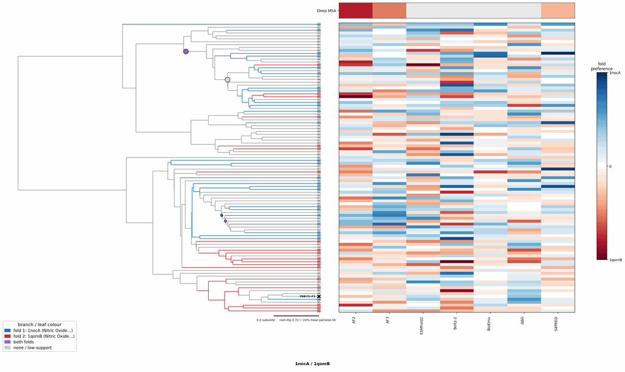

## Figure 2: Aligned overlay (both folds superposed)

The single fold-switching chain of each fold superposed by TM-align; waters hidden, any ligand shown as green sticks. Grey = structurally conserved core, colour = divergent (fold-switching) region.

1nocA (Nitric Oxide Synthase) · dimer1qomB (Nitric Oxide Synthase) · monomerLigand HEM|IMD (bound to 1nocA), Ligand H4B|HEM (bound to 1qomB)

TM-score: 0.879 · Trigger class: protein_binding

Aligned overlay

Loading...

## Figure 3: The two folds, side by side

Each fold is coloured by per-residue Cα deviation between the two superposed structures: grey ≈ conserved core, full colour = structurally divergent (fold-switching) region.

1nocA (Nitric Oxide Synthase)

1qomB (Nitric Oxide Synthase)

0 Å5≥10 Å

1nocA (Nitric Oxide Synthase)

Loading...

1qomB (Nitric Oxide Synthase)

Loading...

## Figure 4: Best-cluster predicted contact maps over the two true folds.

Predicted contact maps (MSA-Transformer) for the clusters best matching each fold, over the true contacts of fold 1 (upper triangle) and fold 2 (lower). Divergent contacts between clusters are the contact-level signature of fold-switching.

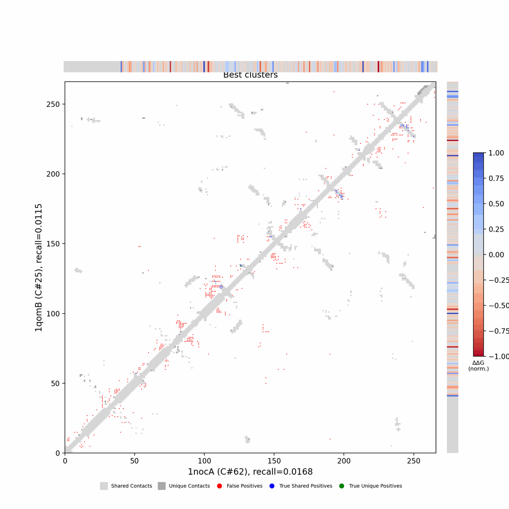

## Figure 5: Per-residue ΔΔG fold-preference contribution

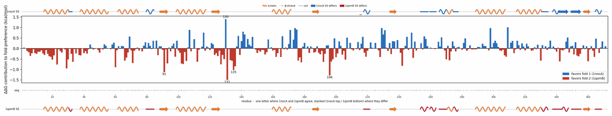

**More figures**

## Figure 6: Deep-MSA contact map panel / Best clusters contact map panel

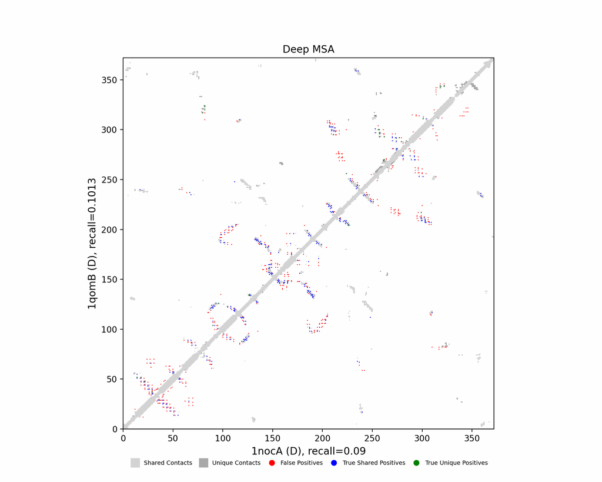

Deep-MSA contact map panel

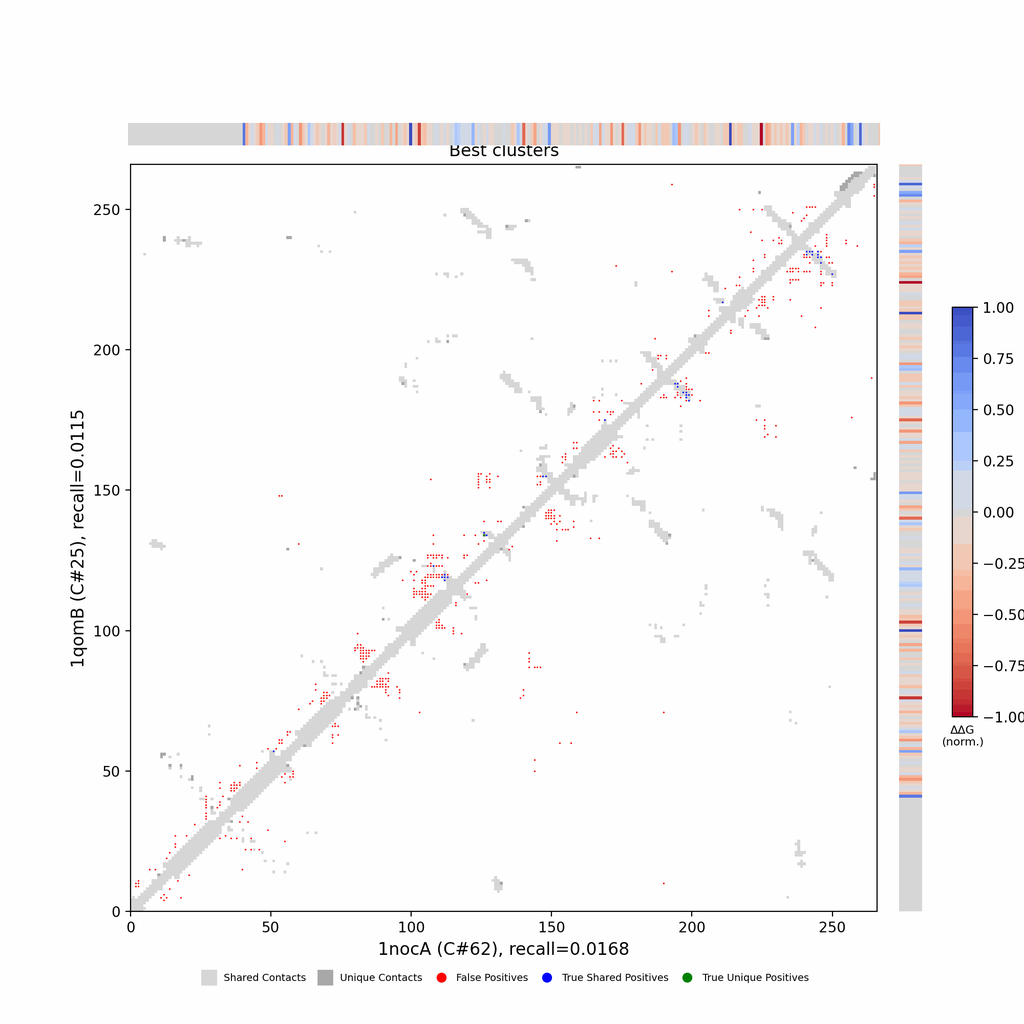

Best clusters contact map panel

## Figure 7: All clusters contact-map mosaic (small multiples).

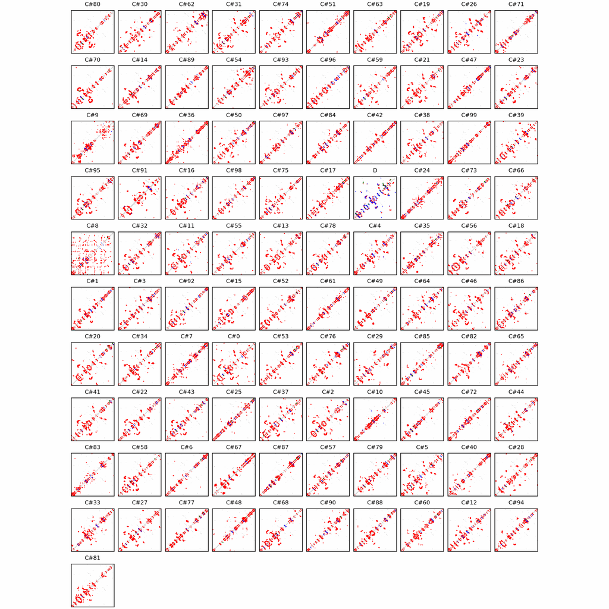

## Figure 8: Phylo null: tree with shuffled cluster fold labels.

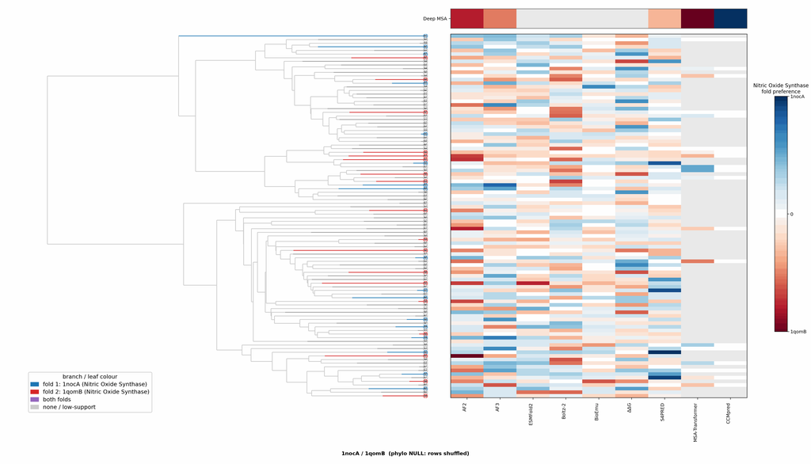

## Cluster metrics table

Per-cluster metrics underlying the figures above.

| cluster | n | neff | AF2_TM1 | AF2_TM2 | AF3_TM1 | AF3_TM2 | RE-MSAT-COM | RE-MSAT1 | RE-MSAT2 | ESM_SEQIDS | ESM_TM1 | ESM_TM2 | ΔΔG_Bias | ΔΔG_Bias_std | ΔΔG_frac_F1 | Boltz2_pref | S4PRED_pref | CCMpred_pref | BioEmu_pref |
| --- | --- | --- | --- | --- | --- | --- | --- | --- | --- | --- | --- | --- | --- | --- | --- | --- | --- | --- | --- |
| Deep | - | - | 0.88 | 0.93 | 0.88 | 0.93 | 0.3 | 0.28 | 0.31 | - | - | - | - | - | - | - | -0.01 | 0.0 | - |
| 000 | 346.0 | 170.0 | 0.48 | 0.46 | 0.53 | 0.49 | 0.01 | 0.01 | 0.01 | 001; 002; 001; 002; 005; 005; 008; 008; 003; 004 | 0.28 ± 0.02 | 0.27 ± 0.02 | -0.6 | 8.01 | 0.5 | -0.03 | -0.01 | 0.0 | 0.0 |
| 001 | 282.0 | 32.0 | 0.3 | 0.26 | 0.29 | 0.28 | 0.01 | 0.01 | 0.01 | 008; 008; 001; 005; 005; 001; 007; 007; 002; 002 | 0.31 ± 0.04 | 0.30 ± 0.03 | -3.92 | 4.09 | 0.3 | -0.02 | -0.01 | 0.0 | 0.01 |
| 002 | 276.0 | 147.0 | 0.28 | 0.28 | 0.61 | 0.55 | 0.01 | 0.02 | 0.01 | 001; 006; 006; 005; 001; 005; 003; 003; 002; 010 | 0.28 ± 0.03 | 0.27 ± 0.02 | -3.03 | 5.91 | 0.2 | 0.02 | -0.01 | 0.0 | 0.01 |
| 003 | 197.0 | 50.0 | 0.33 | 0.29 | 0.32 | 0.37 | 0.0 | 0.0 | 0.01 | 005; 005; 001; 001; 003; 003; 004; 004; 006; 006 | 0.31 ± 0.06 | 0.30 ± 0.04 | -2.14 | 3.53 | 0.3 | 0.04 | -0.01 | 0.0 | -0.01 |
| 004 | 185.0 | 48.0 | 0.26 | 0.24 | 0.35 | 0.33 | 0.02 | 0.02 | 0.02 | 001; 004; 004; 001; 005; 005; 002; 002; 008; 008 | 0.30 ± 0.03 | 0.29 ± 0.03 | -0.75 | 5.64 | 0.4 | -0.01 | -0.01 | 0.0 | 0.01 |
| 005 | 160.0 | 88.0 | 0.22 | 0.21 | 0.31 | 0.3 | 0.03 | 0.03 | 0.02 | 002; 001; 002; 001; 008; 008; 004; 004; 009; 007 | 0.27 ± 0.03 | 0.26 ± 0.02 | -2.02 | 9.06 | 0.4 | 0.02 | -0.0 | 0.0 | 0.02 |
| 006 | 157.0 | 35.0 | 0.23 | 0.24 | 0.32 | 0.31 | 0.0 | 0.0 | 0.01 | 003; 003; 001; 004; 001; 004; 005; 008; 005; 008 | 0.30 ± 0.04 | 0.28 ± 0.04 | -3.77 | 6.67 | 0.4 | -0.01 | -0.02 | 0.0 | 0.01 |
| 007 | 145.0 | 8.0 | 0.26 | 0.26 | 0.24 | 0.25 | 0.0 | 0.0 | 0.0 | 006; 005; 006; 005; 010; 010; 007; 002; 001; 007 | 0.28 ± 0.02 | 0.27 ± 0.03 | -2.17 | 4.02 | 0.2 | -0.01 | -0.01 | 0.0 | 0.01 |
| 008 | 143.0 | 1.0 | 0.31 | 0.29 | 0.34 | 0.33 | 0.0 | 0.0 | 0.0 | 001; 001; 009; 009; 002; 002; 006; 008; 008; 007 | 0.28 ± 0.01 | 0.27 ± 0.03 | 2.16 | 2.65 | 0.7 | -0.01 | -0.01 | 0.0 | 0.01 |
| 009 | 134.0 | 2.0 | 0.25 | 0.23 | 0.3 | 0.3 | 0.0 | 0.0 | 0.0 | 008; 008; 001; 009; 007; 010; 009; 001; 006; 010 | 0.29 ± 0.00 | 0.30 ± 0.02 | -0.2 | 3.69 | 0.5 | -0.01 | -0.01 | 0.0 | 0.0 |
| 010 | 126.0 | 6.0 | 0.3 | 0.27 | 0.34 | 0.32 | 0.0 | 0.0 | 0.0 | 006; 006; 009; 009; 008; 007; 007; 008; 001; 001 | 0.28 ± 0.02 | 0.27 ± 0.02 | -3.52 | 2.77 | 0.1 | -0.01 | -0.01 | 0.0 | -0.0 |
| 011 | 124.0 | 73.0 | 0.35 | 0.38 | 0.62 | 0.58 | 0.01 | 0.01 | 0.02 | 001; 005; 006; 006; 001; 005; 002; 008; 002; 008 | 0.28 ± 0.02 | 0.27 ± 0.03 | -1.89 | 11.26 | 0.5 | 0.02 | -0.01 | 0.0 | 0.0 |
| 012 | 124.0 | 33.0 | 0.2 | 0.18 | 0.25 | 0.24 | 0.03 | 0.03 | 0.03 | 005; 005; 001; 007; 008; 008; 001; 010; 010; 004 | 0.28 ± 0.02 | 0.27 ± 0.03 | -4.35 | 3.65 | 0.0 | 0.0 | -0.01 | 0.0 | 0.01 |
| 013 | 122.0 | 74.0 | 0.4 | 0.37 | 0.71 | 0.62 | 0.0 | 0.0 | 0.0 | 001; 001; 004; 009; 010; 009; 004; 010; 002; 002 | 0.31 ± 0.06 | 0.30 ± 0.05 | -3.55 | 3.37 | 0.2 | -0.03 | -0.0 | 0.0 | 0.02 |
| 014 | 121.0 | 40.0 | 0.43 | 0.45 | 0.68 | 0.6 | 0.0 | 0.0 | 0.0 | 001; 001; 002; 002; 003; 003; 007; 009; 007; 009 | 0.30 ± 0.02 | 0.31 ± 0.03 | 0.31 | 6.94 | 0.6 | -0.0 | -0.0 | 0.0 | 0.0 |
| 015 | 118.0 | 23.0 | 0.32 | 0.35 | 0.49 | 0.5 | 0.01 | 0.01 | 0.02 | 009; 005; 005; 004; 001; 009; 008; 008; 006; 001 | 0.29 ± 0.02 | 0.29 ± 0.03 | -3.91 | 4.61 | 0.1 | -0.02 | -0.02 | 0.0 | -0.0 |
| 016 | 117.0 | 37.0 | 0.28 | 0.3 | 0.32 | 0.31 | 0.0 | 0.0 | 0.0 | 007; 004; 001; 006; 005; 001; 006; 005; 004; 003 | 0.28 ± 0.01 | 0.27 ± 0.02 | 1.24 | 6.66 | 0.5 | 0.02 | -0.01 | 0.0 | 0.01 |
| 017 | 111.0 | 24.0 | 0.2 | 0.21 | 0.35 | 0.34 | 0.01 | 0.01 | 0.01 | 010; 010; 007; 002; 002; 007; 009; 001; 008; 001 | 0.29 ± 0.02 | 0.30 ± 0.03 | -3.37 | 7.87 | 0.3 | 0.01 | 0.02 | 0.0 | 0.01 |
| 018 | 110.0 | 59.0 | 0.34 | 0.3 | 0.7 | 0.63 | 0.01 | 0.01 | 0.01 | 001; 004; 001; 007; 008; 008; 005; 007; 005; 004 | 0.29 ± 0.01 | 0.28 ± 0.01 | -4.16 | 4.51 | 0.2 | -0.02 | -0.01 | 0.0 | 0.0 |
| 019 | 110.0 | 40.0 | 0.25 | 0.23 | 0.65 | 0.62 | 0.01 | 0.01 | 0.02 | - | - | - | -4.09 | 6.05 | 0.3 | 0.01 | -0.01 | - | 0.01 |
| 020 | 108.0 | 53.0 | 0.33 | 0.32 | 0.4 | 0.39 | 0.01 | 0.01 | 0.01 | - | - | - | -4.31 | 5.47 | 0.2 | 0.01 | -0.01 | - | 0.02 |
| 021 | 108.0 | 52.0 | 0.27 | 0.29 | 0.7 | 0.61 | 0.0 | 0.01 | 0.0 | - | - | - | -3.97 | 4.38 | 0.3 | 0.01 | -0.01 | - | 0.01 |
| 022 | 108.0 | 44.0 | 0.6 | 0.55 | 0.72 | 0.62 | 0.0 | 0.0 | 0.0 | - | - | - | -1.66 | 5.07 | 0.4 | -0.03 | -0.01 | - | 0.03 |
| 023 | 107.0 | 44.0 | 0.39 | 0.37 | 0.65 | 0.6 | 0.01 | 0.01 | 0.01 | - | - | - | -5.98 | 3.77 | 0.1 | 0.01 | -0.01 | - | 0.02 |
| 024 | 105.0 | 6.0 | 0.33 | 0.31 | 0.34 | 0.33 | 0.0 | 0.0 | 0.0 | - | - | - | -4.27 | 4.08 | 0.3 | -0.02 | -0.01 | - | 0.0 |
| 025 | 104.0 | 10.0 | 0.26 | 0.27 | 0.43 | 0.41 | 0.0 | 0.0 | 0.0 | - | - | - | -0.69 | 4.85 | 0.4 | 0.02 | -0.02 | - | 0.01 |
| 026 | 100.0 | 46.0 | 0.3 | 0.27 | 0.32 | 0.29 | 0.04 | 0.04 | 0.03 | - | - | - | 2.13 | 5.4 | 0.5 | 0.03 | -0.02 | - | 0.0 |
| 027 | 99.0 | 35.0 | 0.34 | 0.32 | 0.32 | 0.32 | 0.0 | 0.0 | 0.0 | - | - | - | -2.84 | 5.81 | 0.4 | -0.02 | -0.02 | - | 0.01 |
| 028 | 98.0 | 23.0 | 0.28 | 0.29 | 0.27 | 0.25 | 0.0 | 0.0 | 0.0 | - | - | - | -3.95 | 5.86 | 0.2 | 0.0 | -0.01 | - | 0.01 |

[output cut: 71 more lines]